# Lab 3: Saskov

# Задание 9

reforest.csv Файл содержит данные о лесовосстановлении (в тысяч га), полученные из регионального ежегодника Росстата за 2017 год. Файл содержит колонку с названием субъекта и еще 8 колонок с данными по годам. В файле есть пропущенные значения.

Удалите строки, в которых есть пропущенные значения и приведите данные к формату tidydata. Отобразите динамику лесовосстановления по годам с помощью линейного графика для любого из федеральных округов, обозначив субъекты федерации разными цветами. Подпишите значения на графике. Отрегулируйте местоположение подписей так, чтобы рисунок был максимально наглядным. Придумайте новые назания графика и осей.

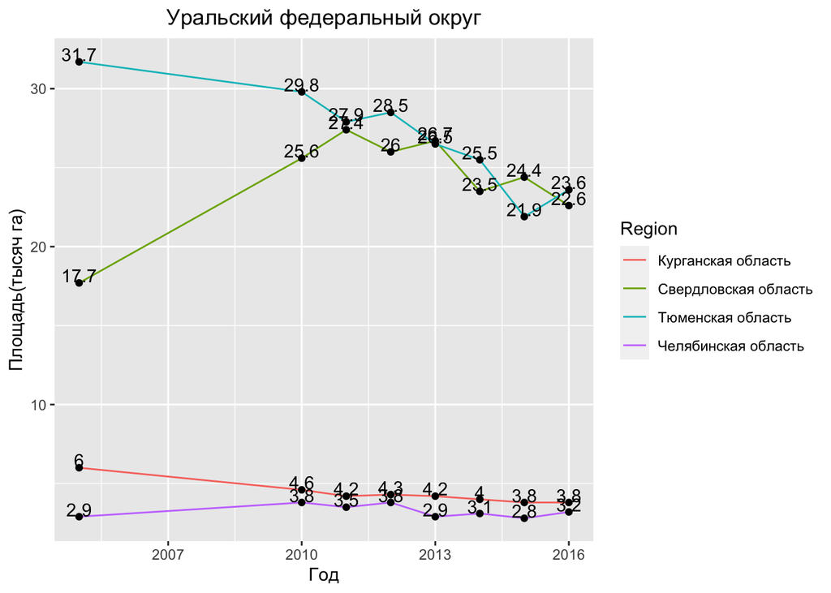

```r
library(dplyr, warn.conflicts = FALSE)
library(stringr)
library(tidyr)
library(readr)
library(ggplot2)

setwd("/Users/lev.saskov/MyProgramms/Univercity/LessonsR/studyR/data")

data <- read_csv("reforest.csv", na = c("-", "NA"))
fixed <- drop_na(data)
is_distr <- str_detect(fixed$Region, "федеральный округ")
distr_num <- 6
begin <- which(is_distr == "TRUE")[distr_num] + 1
end <- which(is_distr == "TRUE")[distr_num + 1] - 1
regions <- fixed[begin:end, ]
another <- pivot_longer(regions, !Region, names_to = "year", values_to = "value") |>
  mutate(year = as.numeric(year))

my_plot <- ggplot(another) +
  geom_line(mapping = aes(x = year, y = value, color = Region)) +
  geom_point(mapping = aes(x = year, y = value))
my_plot <- my_plot + geom_text(aes(x = year, y = value, label = value), vjust = 0, nudge_y = 0.05)
my_plot <- my_plot + xlab("Год") + ylab("Площадь(тысяч га)") + ggtitle(fixed$Region[[begin - 1]]) + theme(plot.title = element_text(hjust = 0.5))
print(my_plot)
```

# Задание 14

В файлах содержатся значения фенотипических признаков сортов сои. Количественные признаки: Height, Protein, Oil, Productivity, GermBMatur. Качественные признаки: GrowthType, Polegaemost, MaturType. Идентификаторы сортов: V_1, V_2, …

data2.csv, data1.txt Объедините data.frames по идентификаторам сортов. Исключите те сорта, для которых есть пропущенные значения. Для всех наблюдаемых величин из файла test_data1.txt (из первого дз), в которых содержится не более 80% пропущенных значений нарисовать гистограммы. Найтите корреляции Пирсона для количественных переменных. Постройте тепловую карту (heatmap).

## Подзадача 14.1.

data2.csv, data1.txt Объедините data.frames по идентификаторам сортов. Исключите те сорта, для которых есть пропущенные значения.

```r
library(dplyr, warn.conflicts = FALSE)
library(stringr)
library(tidyr)
library(ggplot2)

setwd("/Users/lev.saskov/MyProgramms/Univercity/LessonsR/studyR/data")

countable_signs_unf <- read.csv("data2.csv")
countable_signs <- countable_signs_unf |> pivot_longer(!X, names_to = "Sample", values_to = "vals", values_drop_na = TRUE) |>
  pivot_wider(names_from = X, values_from = vals)

quality_signs_unf <- read.table("data1.txt", header = TRUE, skip = 1,)
quality_signs <- quality_signs_unf[, colnames(quality_signs_unf)[2:5]] |> drop_na()

res <- merge(countable_signs, quality_signs, by = "Sample")

res
```

| Sample | GrowthType | Polegaemost | GenmBMatur | MaturType | Height | Protein | Oil |
| --- | --- | --- | --- | --- | --- | --- | --- |
| V_0 | 0 | 1 | 123 | 5 | 92.5 | 39.8 | 16.5 |
| V_100 | 1 | 0 | 95 | 2 | 62.5 | 41.8 | 20.9 |
| V_11 | 1 | 0 | 92 | 2 | 42.5 | 40.7 | 15.1 |
| V_12 | 2 | 2 | 133 | 5 | 97.5 | 43.1 | 18.4 |
| V_13 | 0 | 0 | 118 | 4 | 92.5 | 42.6 | 20.2 |
| V_14 | 0 | 2 | 113 | 4 | 82.5 | 42.4 | 19.5 |
| V_17 | 2 | 0 | 131 | 5 | 107.5 | 42.7 | 16.7 |
| V_19 | 1 | 0 | 95 | 2 | 57.5 | 39.8 | 18.3 |
| V_2 | 0 | 0 | 137 | 5 | 112.5 | 42.1 | 18.3 |
| V_20 | 2 | 0 | 102 | 3 | 52.5 | 41.1 | 21.3 |

[output cut: 76 more lines]

## Подзадача 14.2.

Для всех наблюдаемых величин из файла data1.txt (из первого дз), в которых содержится не более 80% пропущенных значений нарисовать гистограммы.

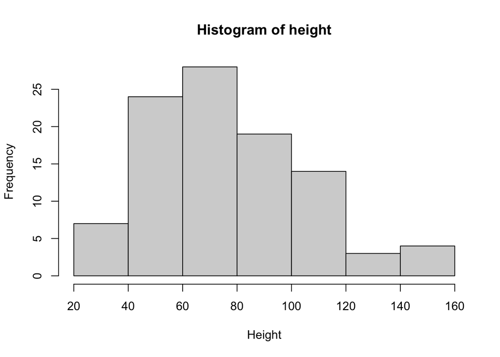

```r
setwd("/Users/lev.saskov/MyProgramms/Univercity/LessonsR/studyR/data")

df <- read.table("data1.txt", header = TRUE, skip = 1,)
df <- quality_signs_unf[, colnames(quality_signs_unf)[2:5]]
# Условие про 80 процентов очень странное, там везде меньше 80 процентов
# Строим гистограмму для Height:
hist(df$Height, main = "Histogram of height", xlab = "Height")
```

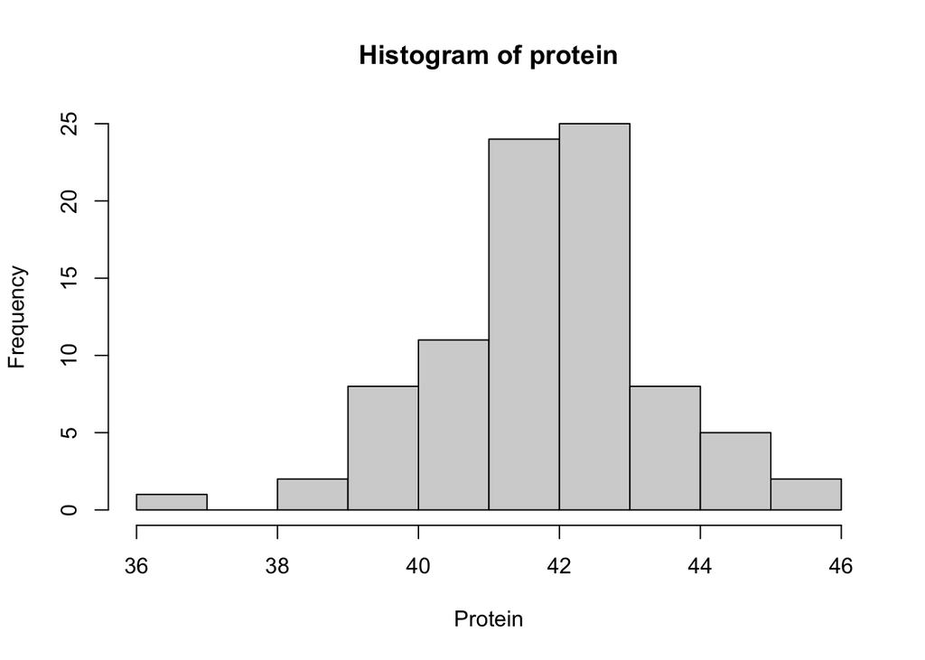

```r
# Строим гистограмму для Height:
hist(df$Protein, main = "Histogram of protein", xlab = "Protein")
```

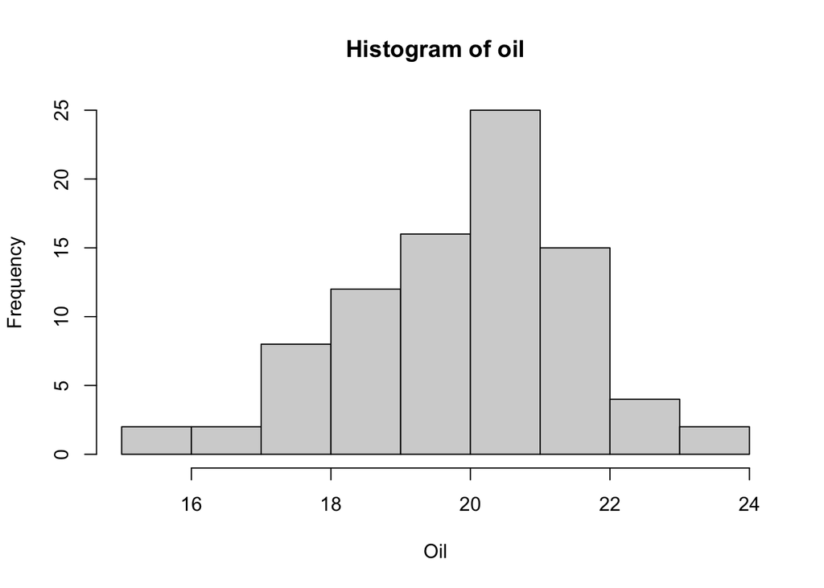

```r
# Строим гистограмму для Height:
hist(df$Oil, main = "Histogram of oil", xlab = "Oil")
```

# Подзадача 14.3.

Построение heatmap для коэффициента Пирсона у количественных переменных.

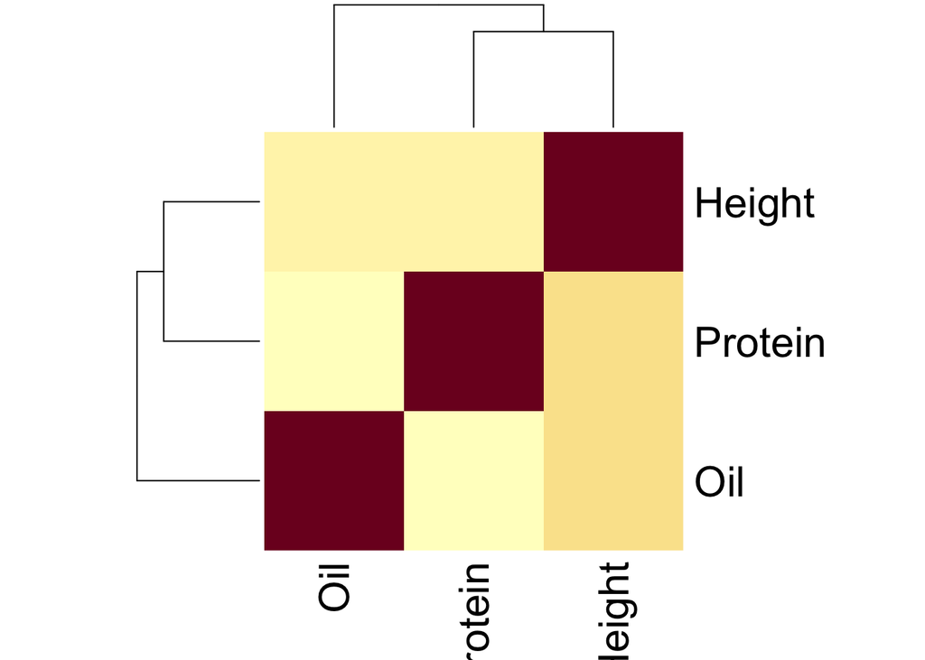

```r
fixed <- drop_na(df)[2:4]
cormat <- cor(fixed)
heatmap(cormat)
```